# MultComp_HW

Evgeniia Molokova

2022-11-22

# Настройка библиотек

# 1. Загрузка данных и создание исследуемой выборки

```r
soccer_general <- read.csv("C:/Users/Евгения/Downloads/soccer.csv", sep=";")[, 2:6] %>%
  mutate(Position = as.factor(Position),
         Nationality = as.factor(Nationality),
         Age = as.numeric(Age),
         Height = as.numeric(Height)) %>%
  filter(Nationality %in% c("Spanish", "Italian", "German", "English", "Argentinian"))

set.seed(1)

soccer_wrk <- soccer_general[sample(1:nrow(soccer_general), 150), ] %>%
  mutate(Nationality = factor(Nationality))
```

# 2. Создание переменных по выборке (вектор значений роста по каждой позиции); по генеральной совокупности (истинные средние значения роста по каждой позиции)

```r
a <- soccer_wrk %>% filter(Position == "Defender") %>% pull(Height) # вектор значений переменной Рост у Защитников

b <- soccer_wrk %>% filter(Position == "Midfielder") %>% pull(Height) # вектор значений переменной Рост у Полузащитников

c <- soccer_wrk %>% filter(Position == "Goalkeeper") %>% pull(Height) # вектор значений переменной Рост у Вратарей

d <- soccer_wrk %>% filter(Position == "Forward") %>% pull(Height) # вектор значений переменной Рост у Нападающих


atrue <- soccer_general %>% filter(Position == "Defender") %>% pull(Height) %>% mean(na.rm = TRUE) #истинное среднее значение Роста (в генеральной совокупности) у Защитников

btrue <- soccer_general %>% filter(Position == "Midfielder") %>% pull(Height) %>% mean(na.rm = TRUE) #истинное среднее значение Роста (в генеральной совокупности) у Полузащитников

ctrue <-  soccer_general %>% filter(Position == "Goalkeeper") %>% pull(Height) %>% mean(na.rm = TRUE) #истинное среднее значение Роста (в генеральной совокупности) у Вратарей

dtrue <- soccer_general %>% filter(Position == "Forward") %>% pull(Height) %>% mean(na.rm = TRUE) #истинное среднее значение Роста (в генеральной совокупности) у Нападающих
```

# ДИ для разницы между средними без поправки и с проправкой Бонферонни (для каждого из 6 интервалов alpha adj. = 0.05/6 = 0.008)

```r
atrue - btrue #Истинное значение разницы средних между Защитниками и Полузащитниками
```

```
## [1] 4.083288
```

```r
t.test(a,b)%>% with (conf.int) #ДИ построенный для разницы средних по выборке
```

```
## [1] 2.061467 6.374897
## attr(,"conf.level")
## [1] 0.95
```

```r
t.test (a,b, conf.level = 0.992) %>% with (conf.int) #ДИ построенный для разницы средних по выборке с поправкой Бонферонни
```

```
## [1] 1.272400 7.163963
## attr(,"conf.level")
## [1] 0.992
```

Вывод: ДИ без поправки и с поправкой покрывает истинную разницу средних. ДИ с поправкой Бонферонни “шире”.

# ДИ для разницы между средними без поправки и с проправкой Бонферонни (для каждого из 6 интервалов alpha adj. = 0.05/6 = 0.008)

```r
ctrue - atrue #Истинное значение разницы средних между Защитниками и Вратарями
```

```
## [1] 5.256514
```

```r
t.test(c,a)%>% with (conf.int) #ДИ построенный для разницы средних по выборке
```

```
## [1] 2.630114 7.885903
## attr(,"conf.level")
## [1] 0.95
```

```r
t.test (c,a, conf.level = 0.992) %>% with (conf.int) #ДИ построенный для разницы средних по выборке с поправкой Бонферонни
```

```
## [1] 1.618540 8.897478
## attr(,"conf.level")
## [1] 0.992
```

Вывод: ДИ без поправки и с поправкой покрывает истинную разницу средних. ДИ с поправкой Бонферонни “шире”.

# ДИ для разницы между средними без поправки и с проправкой Бонферонни (для каждого из 6 интервалов alpha adj. = 0.05/6 = 0.008)

```r
atrue - dtrue #Истинное значение разницы средних между Защитниками и Нападающими
```

```
## [1] 3.318329
```

```r
t.test(a,d)%>% with (conf.int) #ДИ построенный для разницы средних по выборке
```

```
## [1] -1.525215  4.961579
## attr(,"conf.level")
## [1] 0.95
```

```r
t.test (a,d, conf.level = 0.992) %>% with (conf.int) #ДИ построенный для разницы средних по выборке с поправкой Бонферонни
```

```
## [1] -2.758334  6.194698
## attr(,"conf.level")
## [1] 0.992
```

Вывод: ДИ без поправки и с поправкой покрывает истинную разницу средних. ДИ с поправкой Бонферонни “шире”.Однако оба ДИ также покрывают и 0 (отсутствие разницы средних).

# ДИ для разницы между средними без поправки и с проправкой Бонферонни (для каждого из 6 интервалов alpha adj. = 0.05/6 = 0.008)

```r
ctrue - btrue #Истинное значение разницы средних между Полузащитниками и Вратарями
```

```
## [1] 9.339802
```

```r
t.test(c,b)%>% with (conf.int) #ДИ построенный для разницы средних по выборке
```

```
## [1]  6.658979 12.293402
## attr(,"conf.level")
## [1] 0.95
```

```r
t.test (c,b, conf.level = 0.992) %>% with (conf.int) #ДИ построенный для разницы средних по выборке с поправкой Бонферонни
```

```
## [1]  5.591545 13.360836
## attr(,"conf.level")
## [1] 0.992
```

Вывод: ДИ без поправки и с поправкой покрывает истинную разницу средних. ДИ с поправкой Бонферонни “шире”.

# ДИ для разницы между средними без поправки и с проправкой Бонферонни (для каждого из 6 интервалов alpha adj. = 0.05/6 = 0.008)

```r
ctrue - dtrue #Истинное значение разницы средних между Нападающими и Вратарями
```

```
## [1] 8.574843
```

```r
t.test(c,d)%>% with (conf.int) #ДИ построенный для разницы средних по выборке
```

```
## [1]  3.293399 10.658982
## attr(,"conf.level")
## [1] 0.95
```

```r
t.test (c,d, conf.level = 0.992) %>% with (conf.int) #ДИ построенный для разницы средних по выборке с поправкой Бонферонни
```

```
## [1]  1.908202 12.044179
## attr(,"conf.level")
## [1] 0.992
```

Вывод: ДИ без поправки и с поправкой покрывает истинную разницу средних. ДИ с поправкой Бонферонни “шире”.

# ДИ для разницы между средними без поправки и с проправкой Бонферонни (для каждого из 6 интервалов alpha adj. = 0.05/6 = 0.008)

```r
dtrue - btrue #Истинное значение разницы средних между Нападающими и Полузащитниками
```

```
## [1] 0.7649594
```

```r
t.test(d,b)%>% with (conf.int) #ДИ построенный для разницы средних по выборке
```

```
## [1] -0.8976773  5.8976773
## attr(,"conf.level")
## [1] 0.95
```

```r
t.test (d,b, conf.level = 0.992) %>% with (conf.int) #ДИ построенный для разницы средних по выборке с поправкой Бонферонни
```

```
## [1] -2.176105  7.176105
## attr(,"conf.level")
## [1] 0.992
```

Вывод: ДИ без поправки и с поправкой покрывает истинную разницу средних. ДИ с поправкой Бонферонни “шире”. Однако оба ДИ также покрывают 0 (отсутствие разницы средних)

Таким образом, построенные по выборке ДИ покрывают истинную разницу средних в каждой паре как с использованием поправки, так и без. Однако два интервала, построенные по выборке, покрывают также 0 - отсутствие разницы средних. Это было выявлено в парах Защитники-Нападающие и Полузащитники-Нападающие. При этом истинные разницы в средних для этих пар отличны от 0 в генеральной совокупности.

Визуализируем распределение переменной Рост в каждой группе в выборке и генеральной совокупности.

# Графическое представление

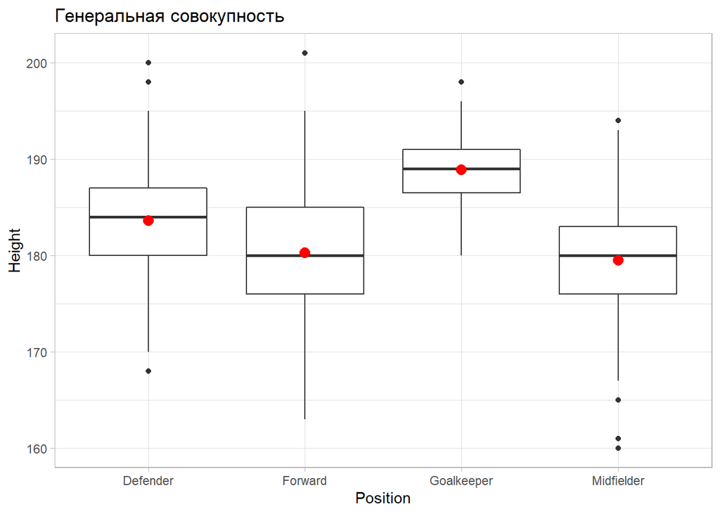

```r
ggplot(data=soccer_general, aes (x=Position, y=Height))+
  geom_boxplot()+
  stat_summary(fun = mean, geom="point", shape=20, size=5, color="red", fill="red")+
  theme_light()+
    ggtitle('Генеральная совокупность')
```

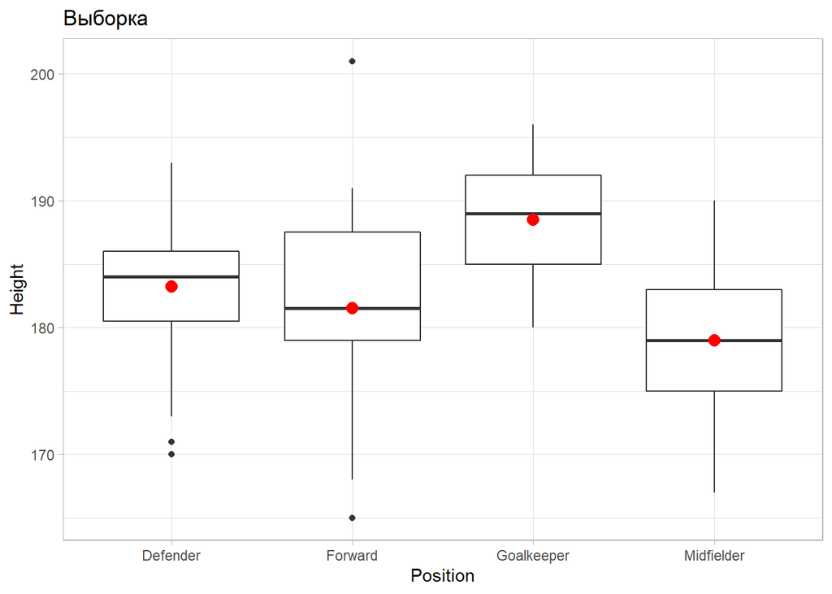

```r
ggplot(data=soccer_wrk, aes (x=Position, y=Height))+
  geom_boxplot()+
  stat_summary(fun = mean, geom="point", shape=20, size=5, color="red", fill="red")+
  theme_light()+
    ggtitle('Выборка')
```

Красным кружком отмечены средние в каждой группе. ДИ, построенные по выборке, покрывают 0 для двух пар: Defender и Forward, Midfielder и Forward. Это можно проинтерпретировать как отсутствие разницы средних, хотя в генеральной совокупности разность между истинными средними не равна 0. Она минимальна для пары Midfielder и Forward (0.8)

# Тесты для разницы средних в каждой паре

```r
t.test(a,b)%>% with (p.value)
```

```
## [1] 0.0001979437
```

```r
t.test(a,c)%>% with (p.value)
```

```
## [1] 0.0002568598
```

```r
t.test(a,d)%>% with (p.value)
```

```
## [1] 0.2910604
```

```r
t.test(c,b)%>% with (p.value)
```

```
## [1] 2.507505e-08
```

```r
t.test(c,d)%>% with (p.value)
```

```
## [1] 0.0003939769
```

```r
t.test(d,b)%>% with (p.value)
```

```
## [1] 0.1455887
```

Вывод: по результатам тестов для разницы средних, выявлены статистически значимые разницы в средних в 4-х парах. Не отвергаем нулевую гипотезу о разнице средних равной 0 в двух парах: Midfielder и Forward, Defender и Forward, что совпадает с предположением, сделанным по ДИ (ДИ в этих парах покрывают 0).

# Попарные тесты для разниц между средними (с поправкой Холма)

```r
pairwise.t.test(soccer_wrk$Height, soccer_wrk$Position, p.adjust.method = "holm", pool.sd = FALSE)
```

```
##
##  Pairwise comparisons using t tests with non-pooled SD
##
## data:  soccer_wrk$Height and soccer_wrk$Position
##
##            Defender Forward Goalkeeper
## Forward    0.29118  -       -
## Goalkeeper 0.00103  0.00118 -
## Midfielder 0.00099  0.29118 1.5e-07
##
## P value adjustment method: holm
```

Вывод: попарный тест с поправкой Холма также выявил статистически значимые разницы в средних в 4-х парах. Не отвергаем нулевую гипотезу о разнице средних равной 0 в двух парах: Midfielder и Forward, Defender и Forward, что совпадает с результатами предыдуших тестов в парах.

# Попарные тесты для разниц между средними (с поправкой Бенджамини-Хохберга)

```r
pairwise.t.test(soccer_wrk$Height, soccer_wrk$Position, p.adjust.method = "BH", pool.sd = FALSE)
```

```
##
##  Pairwise comparisons using t tests with non-pooled SD
##
## data:  soccer_wrk$Height and soccer_wrk$Position
##
##            Defender Forward Goalkeeper
## Forward    0.29106  -       -
## Goalkeeper 0.00051  0.00059 -
## Midfielder 0.00051  0.17471 1.5e-07
##
## P value adjustment method: BH
```

Вывод: попарный тест с поправкой Бенджамини-Хохберга также выявил статистически значимые разницы в средних в 4-х парах. Не отвергаем нулевую гипотезу о разнице средних равной 0 в двух парах: Midfielder и Forward, Defender и Forward, что совпадает с результатами предыдуших тестов в парах. Таким образом, по результатам всех тестов с поправками и без мы сделали 4 “открытия”.

Если посмотреть на генеральную совокупность:

# Попарные тесты для разниц между средними (с поправкой Холма) в генеральной совокупности

```r
pairwise.t.test(soccer_general$Height, soccer_general$Position, p.adjust.method = "holm", pool.sd = FALSE)
```

```
##
##  Pairwise comparisons using t tests with non-pooled SD
##
## data:  soccer_general$Height and soccer_general$Position
##
##            Defender Forward Goalkeeper
## Forward    4.7e-08  -       -
## Goalkeeper < 2e-16  < 2e-16 -
## Midfielder < 2e-16  0.18    < 2e-16
##
## P value adjustment method: holm
```

# Попарные тесты для разниц между средними (с поправкой Бенджамини-Хохберга) в генеральной совокупности

```r
pairwise.t.test(soccer_general$Height, soccer_general$Position, p.adjust.method = "BH", pool.sd = FALSE)
```

```
##
##  Pairwise comparisons using t tests with non-pooled SD
##
## data:  soccer_general$Height and soccer_general$Position
##
##            Defender Forward Goalkeeper
## Forward    2.8e-08  -       -
## Goalkeeper < 2e-16  < 2e-16 -
## Midfielder < 2e-16  0.18    < 2e-16
##
## P value adjustment method: BH
```

Вывод: попарные тесты в генеральной совокупности выявили статистически значимые разницы в средних уже в 5 парах. Не отвергаем нулевую гипотезу о разнице средних равной 0 только в одной паре: Midfielder и Forward. Таким образом, анализируя выборочные средние мы сделали одно “ложное открытие” - отсутствие разницы между средними в паре Defender- Forward